# Singular Vector Decomposition

Karan Ravindran Pillay

11/20/2019—12/6/2019

## Problem Statement: Given a set of manually classified digits (the training set), classify a set of unknown digits (the test set) using SVD method.

## Data Set

#### Loading the Data…

```r
trI <- read.csv("trainInput.csv",header = FALSE)
trO <- read.csv("trainOutput.csv", header = FALSE)
teI <- read.csv("testInput.csv",header = FALSE)
teO <- read.csv("testOutput.csv", header = FALSE)
```

#### Reorganizing the Data…

```r
trainInput <- t(trI)
trainOutput <- t(trO)
trainData <- cbind(trainInput,trainOutput)
```

## Methodology

#### Form the Matrix *A[[i]]* for Digit i-1(Such That Each Row in *A[[i]]* Represents an Image of Digit i-1).

#### Determine the Singular Value Decomposition of Each *A[[i]]*(and store it in *S[[i]]*).

#### Retrieve the First 20 Singular Images of Each Digit(and store them in *V[[i]]*)

```r
A <- list()
S <- list()
V <- list()
for (i in 1:10){
  A[[i]] <- subset(trainData, trainData[,257] == i-1)[,-257]
  S[[i]] <- svd(A[[i]])
  V[[i]] <- S[[i]]$v[,1:20]
}
```

#### Express Test Images as a Linear Combination of the First k=20 Singular Images of Each Digit.

$$testImage ≈ V[[i]]x$$

#### Compute the Distance Between Test Images and Their Least Square Approximations and Store in *n[i]*.

#### Classify Each Test Image to be the *digit[j]* Corresponding to the Smallest Residual.

```r
library(MASS)
n <- c()
digit <- c()
for (j in 1: ncol(teI)){
  for (i in 1:10) {
  n[i] <- norm(V[[i]] %*% (ginv(V[[i]]) %*% teI[,j]) - teI[j], '2')
  }
  digit[j] <- which.min(n)-1
}
#digit
```

#### Calculate the Overall Correct Classification Rate.

```r
count <- 0
for(i in 1:ncol(teO)){
  if(digit[i] == teO[i]){
    count <- count + 1
  }
}
corrRate <- count/ncol(teO)
corrRate
```

```
## [1] 0.939711
```

#### Calculate the Correct Classification Rate for Each Digit in a Confusion Matrix.

```r
library(knitr)
library(kableExtra)
library(dplyr)
predict <- digit
reference <- t(teO)
confMat <- as.matrix(table(reference,predict))
confMat %>%
  kable(format = "html", caption = "Classification Correct Rate: Reference | Predict -->") %>%
  kable_styling(font = 20) %>%
  row_spec(0, bold = T, color = "tomato")
```

Classification Correct Rate: Reference | Predict –>

|  | 0 | 1 | 2 | 3 | 4 | 5 | 6 | 7 | 8 | 9 |
| --- | --- | --- | --- | --- | --- | --- | --- | --- | --- | --- |
| 0 | 355 | 0 | 2 | 0 | 1 | 0 | 0 | 0 | 0 | 1 |
| 1 | 0 | 259 | 0 | 0 | 3 | 0 | 2 | 0 | 0 | 0 |
| 2 | 8 | 1 | 179 | 2 | 3 | 0 | 0 | 1 | 4 | 0 |
| 3 | 1 | 0 | 4 | 148 | 1 | 8 | 0 | 1 | 2 | 1 |
| 4 | 1 | 1 | 0 | 0 | 187 | 1 | 1 | 3 | 0 | 6 |
| 5 | 8 | 1 | 2 | 4 | 0 | 140 | 0 | 0 | 2 | 3 |
| 6 | 2 | 0 | 0 | 0 | 2 | 2 | 164 | 0 | 0 | 0 |
| 7 | 0 | 1 | 1 | 0 | 3 | 0 | 0 | 139 | 0 | 3 |
| 8 | 4 | 0 | 2 | 6 | 0 | 1 | 0 | 0 | 149 | 4 |
| 9 | 0 | 1 | 0 | 1 | 4 | 0 | 0 | 4 | 1 | 166 |

```r
rate <- c()
for (i in 1:10){
  rate[i] <- confMat[i,i]/rowSums(confMat)[i]
}

df <- cbind(c(0:9),rate)
colnames(df) <- c("Digit", "CorrRate")
df %>%
  kable(format = "html", caption = "Classification Correct Rate") %>%
  kable_styling(font = 20) %>%
  row_spec(0, bold = T, color = "tomato")
```

Classification Correct Rate

| Digit | CorrRate |
| --- | --- |
| 0 | 0.9888579 |
| 1 | 0.9810606 |
| 2 | 0.9040404 |
| 3 | 0.8915663 |
| 4 | 0.9350000 |
| 5 | 0.8750000 |
| 6 | 0.9647059 |
| 7 | 0.9455782 |
| 8 | 0.8975904 |
| 9 | 0.9378531 |

### Summary

For R Command:  
a. n[3] != n[3] without firstly define n  
b. dataframe[,1] != dataframe[1]. as.matrix(df[,1]) == df[1]  
c. which.min() is for retrieving index of minimum.  
For SVD Application:  
a. Model Comes From V  
b. Using First a Few Concepts Not Features to Represent the Whole  
c. Least Square Method is for Comparing and Classifying  
For Accuracy Result Interpretation:

```r
cat("The Highest Predict Accuracy is for Digit: ", which.max(rate)-1,
    "\nThe Lowest Predict Accuray is for Digit: ", which.min(rate)-1)
```

```
## The Highest Predict Accuracy is for Digit:  0
## The Lowest Predict Accuray is for Digit:  5
```

Possiblely because:

```r
for(i in 1:10){
  cat("Digit", i-1, "'s Matrix Dimension is", dim(A[[i]]),"\n")
}
```

```
## Digit 0 's Matrix Dimension is 319 256
## Digit 1 's Matrix Dimension is 252 256
## Digit 2 's Matrix Dimension is 202 256
## Digit 3 's Matrix Dimension is 131 256
## Digit 4 's Matrix Dimension is 122 256
## Digit 5 's Matrix Dimension is 88 256
## Digit 6 's Matrix Dimension is 151 256
## Digit 7 's Matrix Dimension is 166 256
## Digit 8 's Matrix Dimension is 144 256
## Digit 9 's Matrix Dimension is 132 256
```

From which, we can see:

```r
num_sample <- c()
for(i in 1:10){
  num_sample[i] <- nrow(A[[i]])
  #cat("Digit", i-1, "'s Has", num_sample[i]," Samples\n")
}
cat("The Digit that Has the Largest Sample Number in Training Dataset is ", which.max(num_sample)-1,
    "\nThe Digit that Has the Lowest Sample Number in Training Dataset is: ", which.min(num_sample)-1)
```

```
## The Digit that Has the Largest Sample Number in Training Dataset is  0
## The Digit that Has the Lowest Sample Number in Training Dataset is:  5
```

```r
df <- cbind(num_sample, rate)
```

```r
library(psych)
```

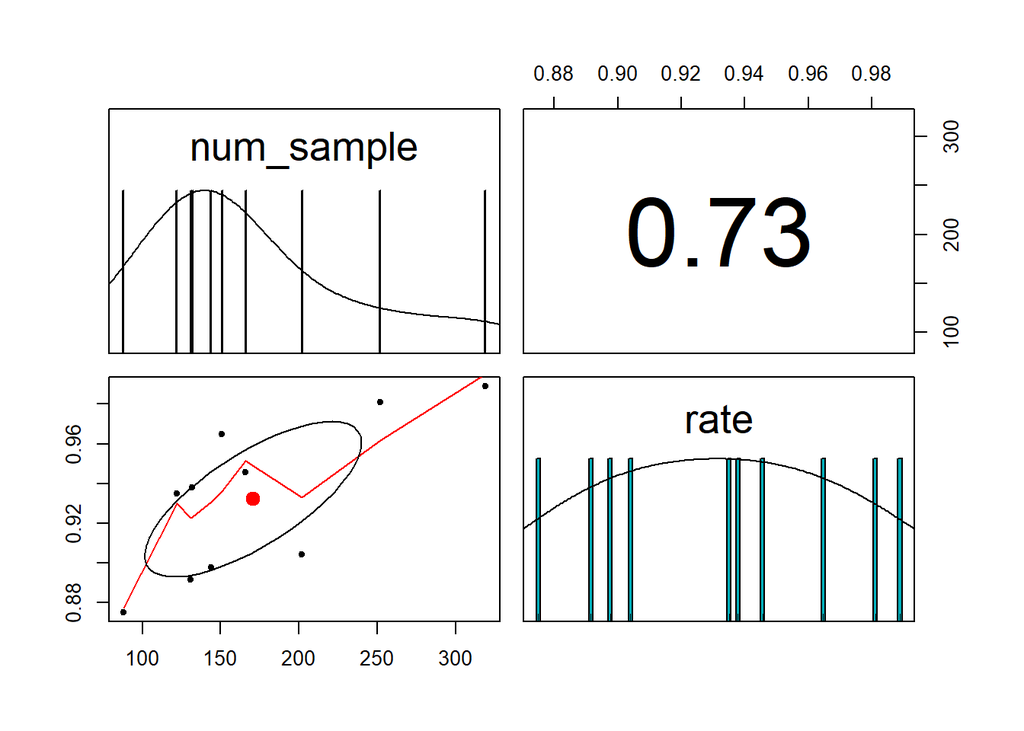

```r
options(repr.plot.width=5, repr.plot.height=5)
pairs.panels(df[,c("num_sample", "rate")],
             method = "pearson", # correlation method
             hist.col = "#00AFBB",
             density = TRUE,  # show density plots
             ellipses = TRUE # show correlation ellipses
)
```

#### Thus, we confirm the previous intuitive believe, that the more sample that the model build with, the more accuracy the model may work with.